# Exceptions

An exception is an abnormal condition that arises in a code sequence at run time. In other words, an exception is a run-time error. A Java exception is an object that describes an exceptional condition that has occurred in a piece of code. When an exceptional condition arises, an object representing that exception is created and thrown in the method that caused the error. That method may choose to handle the exception itself, or pass it on. Either way, at some point, the exception is caught and processed.

Java exception handling is managed via five keywords: **try**, **catch**, **throw**, **throws**, and **finally**.

Program statements that you want to monitor for exceptions are contained within a **try** block. If an exception occurs within the try block, it is thrown. Your code can catch this exception (using **catch**) and handle it in some rational manner. System-generated exceptions are automatically thrown by the Java run-time system. To manually throw an exception, use the keyword **throw**. Any exception that is thrown out of a method must be specified as such by a **throws** clause. Any code that absolutely must be executed after a try block completes is put in a **finally** block.

Here is the general form of exception handling:

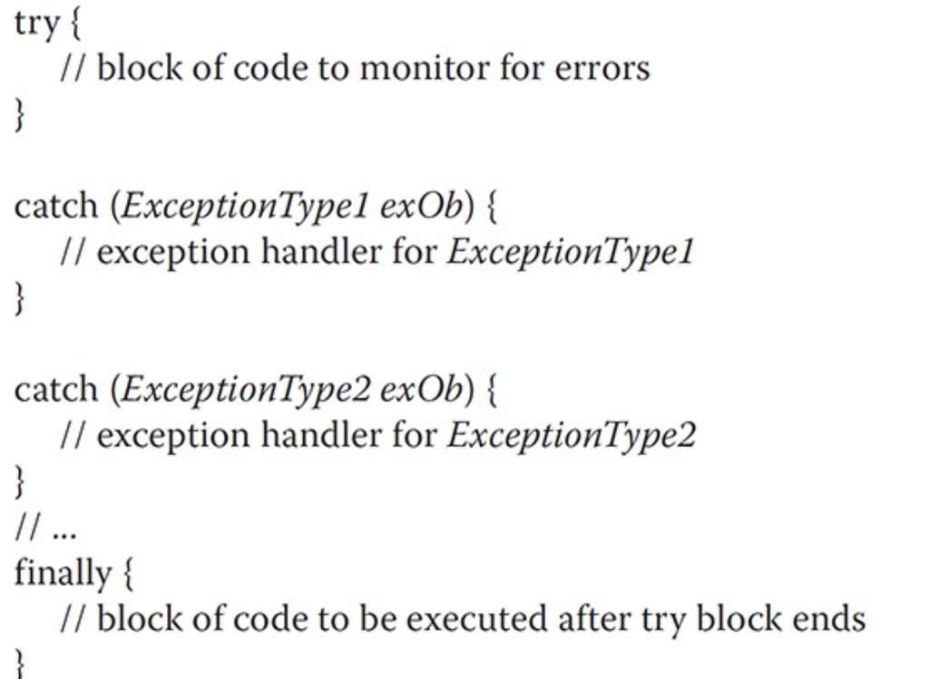

## Exception types

All exception types are subclasses of the built-in class **Throwable**. Thus, Throwable is at the top of the exception class hierarchy. Immediately below **Throwable** are two subclasses that partition exceptions into two distinct branches. One branch is headed by **Exception**. This class is used for exceptional conditions that user programs should catch. This is also the class that you will subclass to create your own custom exception types. There is an important subclass of **Exception**, called **RuntimeException**. Exceptions of this type are automatically defined for the programs that you write and include things such as division by zero and invalid array indexing.

The other branch is topped by **Error**, which defines exceptions that are not expected to be caught under normal circumstances by your program. Exceptions of type **Error** are used by the Java run-time system to indicate errors having to do with the run-time environment, itself.

### Exception hierarchy

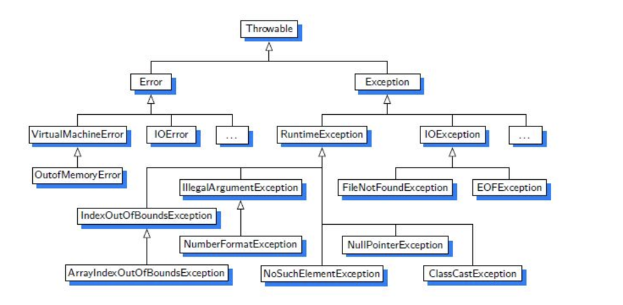

## Uncaugth Exceptions

Lets consider the following example:

```java
class ExceptionDemo {
    public static void main(String... args) {
        int a = 0;
        int b = 10 / a;
        System.out.println("This line will not be executed.");
    }
}
```

```java
ExceptionDemo.main()
```

```
---------------------------------------------------------------------------
java.lang.ArithmeticException: / by zero
	at ExceptionDemo.main(#12:4)
	at .(#14:1)
```

When the Java run-time system detects the attempt to divide by zero, it constructs a new exception object and then throws this exception.

Any exception that is not caught by your program will ultimately be processed by the default handler. The default handler displays a string describing the exception, prints a stack trace from the point at which the exception occurred, and terminates the program.

The stack trace will always show the sequence of method invocations that led up to the error.

```java
class A {
    void a() {
        b();
    }

    void b() {
        c();
    }

    void c() {
        System.out.println(10 / 0);
    }

    public static void main(String... args) {
        A obj = new A();
        obj.a();
    }
}
```

```java
A.main();
```

```
---------------------------------------------------------------------------
java.lang.ArithmeticException: / by zero
	at A.c(#15:11)
	at A.b(#15:7)
	at A.a(#15:3)
	at A.main(#15:16)
	at .(#16:1)
```

## Using Try and Catch

Although the default exception handler provided by the Java run-time system is useful for debugging, you will usually want to handle an exception yourself.

To illustrate how easily this can be done, the following program includes a try block and a catch clause that processes the ArithmeticException generated by the division-by-zero error:

```java
class ExceptionDemo2 {
    public static void main(String... args) {
        int a = 0;
        int b = 5;
        try {
            int c = b / a;
            System.out.println("This line still will not be printed.");
        } catch (ArithmeticException c) {
            System.out.println("Division by zero.");
        }

        System.out.println("This line will be printed.");
    }
}
```

```java
ExceptionDemo2.main();
```

```
Division by zero.
This line will be printed.
```

Notice that the call to println( ) inside the try block is never executed. Once an exception is thrown, program control transfers out of the try block into the catch block.

Catch is not “called,” so execution never “returns” to the try block from a catch. Once the catch statement has executed, program control continues with the next line in the program following the entire try / catch mechanism.

The goal of most well-constructed catch clauses should be to resolve the exceptional condition and then continue on as if the error had never happened.

```java
import java.util.Random;

class RandomDemo {

    public static void main(String... args) {
        Random r = new Random();
        int a = 0;
        int b = 0;
        double c = 0;
        try {
            for (int i = 0; i < 1000; i++) {
                a = r.nextInt(10);
                b = r.nextInt(10);
                c = a / b;
                System.out.println(i);
            }
        } catch (ArithmeticException e) {
            System.out.println("Division by zero");
        }

        System.out.println("After try block");
    }
}
```

```java
RandomDemo.main()
```

```
0
1
2
3
4
5
6
7
8
9
10
11
12
13
14
15
Division by zero
After try block
```

### Describe your exception

Throwable overrides the toString() method (defined by Object) so that it returns a string containing a description of the exception. You can display this description in a println() statement by simply passing the exception as an argument. For example:

```java
class ExceptionDemo3 {

    public static void main(String... args) {
        try {
            int a = 10;
            int b = 0;
            int c = a / b;
        } catch (ArithmeticException e) {
            System.out.println(e);
            e.printStackTrace();
        }
        System.out.println("OK");
    }
}
```

```java
ExceptionDemo3.main();
```

```
java.lang.ArithmeticException: / by zero
```

[output not shown]

```
OK
```

### Multiple catch blocks

In some cases, more than one exception could be raised by a single piece of code. To handle this type of situation, you can specify two or more catch clauses, each catching a different type of exception. When an exception is thrown, each catch statement is inspected in order, and the first one whose type matches that of the exception is executed.

```java
public class MultipleCatchDemo {

    public static void main(String... args) {
        try {
            int[] myArr = {10, 9, 8, 7, 6, 0, 4, 3, 2, 1};
            int b = 0;
            for (int i = 0; i < myArr.length; i++) {
                b = 10 / myArr[i];
            }
        } catch (ArithmeticException e) {
            System.out.println(e);
        } catch (ArrayIndexOutOfBoundsException e) {
            System.out.println(e);
        }

        System.out.println("After try/catch blocks");
    }
}
```

```java
MultipleCatchDemo.main()
```

```
java.lang.ArithmeticException: / by zero
After try/catch blocks
```

When you use multiple catch statements, it is important to remember that exception subclasses must come before any of their superclasses. This is because a catch statement that uses a superclass will catch exceptions of that type plus any of its subclasses.

```java
public class ExcHierarchyDemo {
    public static void main(String... args) {
        try {
            int a = 5 / 0;
        } catch (Exception e) {
            System.out.println(e);
        } catch (ArithmeticException e) {
            System.out.println(e);
        }
    }
}
```

```
|           } catch (ArithmeticException e) {
|               System.out.println(e);
|           }
exception java.lang.ArithmeticException has already been caught
```

```java
public class ExcHierarchyDemo {
    public static void main(String... args) {
        try {
            int a = 5 / 0;
        } catch (ArithmeticException e) {
            System.out.println(e);
        } catch (Exception e) {
            System.out.println(e);
        }
    }
}
```

As you can see we got a compile-time error that indicates that we already caught ArithmeticException in the Exception catch block.

Since ArithmeticException is a subclass of Exception, the first catch statement will handle all Exception-based errors, including ArithmeticException.

## Nested try Statements

The try statement can be nested. That is, a try statement can be inside the block of another try. Each time a try statement is entered, the context of that exception is pushed on the stack.

```java
class NestedTry {
    public static void main(String... args) {
        try {
            int a = args.length;
            int b = 10 / a;
            System.out.println(b);
            try {
                if (a == 1) {
                    a = a / (a - a);
                }
                if (a == 2) {
                    int[] c = {1};
                    c[1] = 100;
                }
            } catch (ArrayIndexOutOfBoundsException e) {
                System.out.println(e);
            }
        } catch (ArithmeticException e) {
            System.out.println(e);
        }
    }
}
```

```java
NestedTry.main("a");
```

```
10
java.lang.ArithmeticException: / by zero
```

```java
NestedTry.main()
```

```
java.lang.ArithmeticException: / by zero
```

```java
NestedTry.main("a", "b");
```

```
5
java.lang.ArrayIndexOutOfBoundsException: Index 1 out of bounds for length 1
```

## Throw

So far, you have only been catching exceptions that are thrown by the Java run- time system. However, it is possible for your program to throw an exception explicitly, using the throw statement.

The flow of execution stops immediately after the throw statement; any subsequent statements are not executed.

```java
class ThrowDemo {
    static void iThrowException(String argument) {
        try {
            if (argument.isEmpty())
                throw new MyCustomException("Message");
        } catch (MyCustomException e) {
            System.out.println("Invalid argument exception.");
            throw new NullPointerException();
        }
    }

    public static void main(String... args) {
       try {
        iThrowException("");
       } catch (Exception e) {
           System.out.println("Recaught in main");
       }
    }

}
```

```java
ThrowDemo.main();
```

[output not shown]

The program also illustrates how to create one of Java’s standard exception objects.  
throw new NullPointerException("NPO");

Here, new is used to construct an instance of NullPointerException. Many of Java’s built-in run-time exceptions have at least two constructors: one with no parameter and one that takes a string parameter. When the second form is used, the argument specifies a string that describes the exception.

## Throws

If a method is capable of causing an exception that it does not handle, it must specify this behavior so that callers of the method can guard themselves against that exception. You do this by including a throws clause in the method’s declaration.

All other exceptions that a method can throw must be declared in the throws clause. If they are not, a compile-time error will result.

```java
public class ThrowsDemo1 {

    public static void myMethod() {
        System.out.println("myMethod");
        throw new IllegalAccessException();
    }

    public static void main(String[] args) {
        myMethod();
    }
}
```

```
|           throw new IllegalAccessException();
unreported exception java.lang.IllegalAccessException; must be caught or declared to be thrown
```

```java
public class ThrowsDemo1 {

    public static void myMethod() throws IllegalAccessException {
        System.out.println("myMethod");
        throw new IllegalAccessException();
    }

    public static void main(String... args) {
           myMethod();
    }
}
```

```
|              myMethod();
unreported exception java.lang.IllegalAccessException; must be caught or declared to be thrown
```

```java
ThrowsDemo1.main();
```

[output not shown]

## Finally

**finally** creates a block of code that will be executed after a try /catch block has completed and before the code following the try/catch block. The finally block will execute whether or not an exception is thrown. This can be useful for closing file handles and freeing up any other resources.

The finally clause is optional. However, each try statement requires at least one catch or a finally clause.

```java
class FinallyDemo {
    public static void methodA() {
        try {
            System.out.println("Inside methodA()");
            throw new NullPointerException("EXCEPTION");
        } finally {
            System.out.println("In finally block of methodA()");
        }
    }

    public static void methodB() {
        try {
            System.out.println("Inside methodB()");
            return;
        } finally {
            System.out.println("In finally block of methodB()");
        }
    }

    public static void methodC() {
        try {
            System.out.println("Inside methodC()");
        } finally {
            System.out.println("In finally block of methodC()");
        }
    }

    public static void main(String... args) {
        try {
            methodA();
        } catch (Exception e) {
            System.out.println("Exception caught");
            System.out.println(e.getMessage());
        }
        methodB();
        methodC();
    }
}
```

```java
FinallyDemo.main();
```

```
Inside methodA()
In finally block of methodA()
Exception caught
EXCEPTION
Inside methodB()
In finally block of methodB()
Inside methodC()
In finally block of methodC()
```

### Java built-in exceptions

Inside the standard package java.lang, Java defines several exception classes. A few have been used by the preceding examples. The most general of these exceptions are subclasses of the standard type RuntimeException. As previously explained, these exceptions need not be included in any method’s throws list. In the language of Java, these are called unchecked exceptions because the compiler does not check to see if a method handles or throws these exceptions.

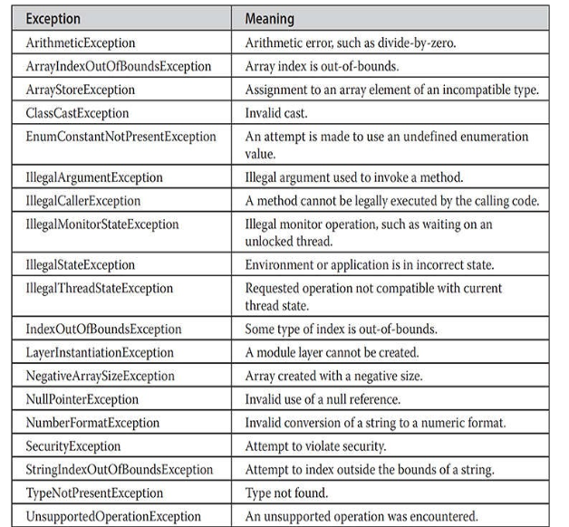

### Creating Your Own Exception Subclasses

You will probably want to create your own exception types to handle situations specific to your applications. This is quite easy to do: just define a subclass of Exception

The Exception class does not define any methods of its own. It does, of course, inherit those methods provided by Throwable. Thus, all exceptions, including those that you create, have the methods defined by Throwable available to them.

Here is two most common contructors which you will use when create your own exceptions:

```
    Excetion()
    Exception(String msg)
```

The first form creates an exception that has no description. The second form lets you specify a description of the exception.

Although specifying a description when an exception is created is often useful, sometimes it is better to override toString( ). Here’s why: The version of toString( ) defined by Throwable (and inherited by Exception) first displays the name of the exception followed by a colon, which is then followed by your description. By overriding toString( ), you can prevent the exception name and colon from being displayed. This makes for a cleaner output, which is desirable in some cases.

```java
class MyException extends Exception {
    private double value;

    public MyException(double d) {
        value = d;
    }

    public String toString() {
        return "MyException[" + value + "]";
    }
}
```

```java
class ExceptionDemo {
    static void compute(double d) throws MyException {
        System.out.println("Inside compute()");
        if (d < 0) {
            throw new MyException(d);
        }
        System.out.println("OK.");
    }

    public static void main(String... args) {
        try {
            compute(0);
            compute(10);
            compute(-1);
        } catch (MyException ex) {
            System.out.println(ex);
        }
    }
}
```

```java
ExceptionDemo.main();
```

```
Inside compute()
OK.
Inside compute()
OK.
Inside compute()
MyException[-1.0]
```